# TP3-MPA

Imad Ez-zejjari

11/25/2020

## Partie 1

## Question 1

$P(y|\theta)=p(y_1,...,y_n)=\prod_{i=1}^{n}p(y_i|\theta)=\prod_{i=1}^{n}\frac{\theta^{y_i}}{y_i!}e^{-\theta}=\frac{\theta^{\sum_{i=1}^{n}y_i}}{\prod_{i=1}^{n}y_i!}e^{-n\theta}$

## Question 2

$P(\theta)\propto\frac{1}{\theta}, \theta\gt0$

$P(\theta|y)=\frac{p(y|\theta)p(\theta)}{P(y)}\propto P(y|\theta)P(\theta)\propto \frac{\theta^{\sum_{i=1}^{n}y_i-1}}{\prod_{i=1}^{n}y_i!}e^{-n\theta}$

$P(y)=\int_0^\infty P(y|\theta)P(\theta) d\theta=\int_0^\infty \frac{\theta^{\sum_{i=1}^{n}y_i-1}}{\prod_{i=1}^{n}y_i!}e^{-n\theta} d\theta=\frac{1}{\prod_{i=1}^{n}y_i!}\int_0^\infty \theta^{\sum_{i=1}^{n}y_i-1}e^{-n\theta} d\theta$

Rappel : Loi Gamma $X\sim\Gamma(k,\theta)$

$f(x,k,\theta)=\frac{x^{k-1}e^{-\frac{x}{\theta}}}{\Gamma(k)\theta^k}, x\gt0$

$k=\sum_{i=1}^{n}y_i$,$\theta=\frac{1}{n}$

$\int_0^\infty \frac{\theta^{\sum_{i=1}^{n}y_i-1}e^{-n\theta}}{\Gamma(\sum_{i=1}^{n}y_i)(\frac{1}{n})^k}=1$

donc $\int_0^\infty\theta^{\sum_{i=1}^{n}y_i-1}e^{-n\theta}=\Gamma(\sum_{i=1}^{n}y_i)(\frac{1}{n})^k$

On a donc $P(y)=\frac{1}{\prod_{i=1}^{n}y_i!}\frac{\Gamma(\sum_{i=1}^{n}y_i)}{n^k}$

$P(\theta|y)=\frac{P(y|\theta)P(\theta)}{P(y)}=\frac{\theta^{\sum_{i=1}^{n}y_i-1}}{\prod_{i=1}^{n}y_i!}e^{-n\theta}\frac{\prod_{i=1}^{n}y_i!n^k}{\Gamma(\sum_{i=1}^{n}y_i)}=\frac{\theta^{\sum_{i=1}^{n}y_i-1}e^{-n\theta}n^k}{\Gamma(\sum_{i=1}^{n}y_i)}$ qui suit une loi gamma de paramétre

$$\sum_{i=1}^{n}y_i$$
et 1/n. Ainsi, l’espérance est
$$(1/n)*\sum_{i=1}^{n}y_i$$

```r
n= 1000
#Tirer y selon la loi de poisson
tirer_y <- function(n){
  theta_initial = 2
  y= c(rpois(n,  theta_initial))
  for (j in 1: n){
    theta_0 = 2
    y = c(y, rpois(1, theta_0))
  }
  theta_initial
  return(theta_initial)
}
#theta_initial = tirer_y(100)
#theta_initial
# Marche bien
#theta_0 = 10
theta_0 = 20

y = rpois(n, theta_0)
somme = sum(y)
theta = rgamma(n, somme, 1/n)
theta[1]
```

```
## [1] 19895626
```

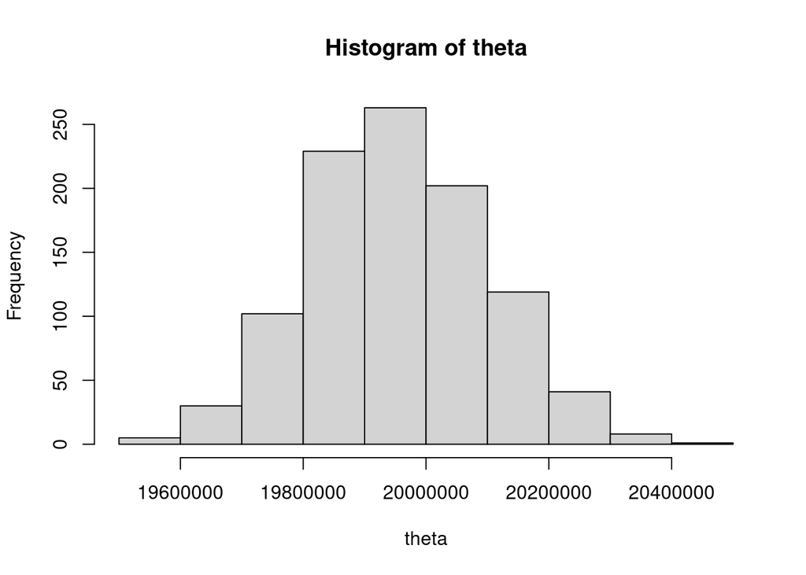

```r
hist(theta)
```

## Question 3

L’algorithme de Metropolis-Hasting se définit à partir des étapes suivantes:

1. Initialiser $\theta^0, t=0$
2. À l’itération t, tirer $\theta^*$ selon la loi instrumentale $q(\theta^t,\theta^*)$
3. Calculer $r=\frac{\pi(\theta^*)q(\theta^*,\theta^t)}{\pi(\theta^t)q(\theta^t,\theta^*)}$
4. Avec la probalité min(1,r):
- faire $\theta^{t+1}\leftarrow \theta^*$
- sinon $\theta^{t+1}\leftarrow \theta^t$
5. Incrémenter t et retourner en 2.

```r
calcul_proba_theta_y <- function(theta, sommes, n){
  y = rpois(10, 2)
  somme = sum(y)
  resultat = (theta**(somme-1))*exp(-n*theta)*(n**(somme))*(1/gamma(somme))
  print(resultat)
  print(theta**(somme-1))
  print(exp(-n*theta))
  print(n**(somme))
  print("d")
  print(1/gamma(somme))
  return(resultat)
}
algo_Metropolis <- function(T, y, t_valeur){
  theta0 = 1
  somme =sum(y)
  theta = c()
  for (temps in 0:T){
    thetanew = rnorm(1, theta0, 1)
    log_rapport = (somme -1)*(log(thetanew) - log(theta0)) -n*(thetanew - theta0) + log(dnorm(theta0, thetanew, 1)-log(dnorm(thetanew, theta0, 1)))
    rapport = exp(log_rapport)
    #print(rapport)
    runiforme = runif(1)
    if (runiforme < rapport){
      theta0 = thetanew
    }
    if (temps > t_valeur){
      theta = c(theta, theta0)
    }
  }
  return(theta)
}
T = 10000
t_valeur = 1000
theta_metropolis = algo_Metropolis(T,y, t_valeur)
```

## Question 4

```r
summary(theta_metropolis)
```

```
##    Min. 1st Qu.  Median    Mean 3rd Qu.    Max.
##   19.45   19.85   19.96   19.96   20.07   20.48
```

```r
cat('La moyenne à posteriori :\n')
```

```
## La moyenne à posteriori :
```

```r
mean(theta_metropolis)
```

```
## [1] 19.96367
```

```r
cat('La mediane à posteriori :\n')
```

```
## La mediane à posteriori :
```

```r
median(theta_metropolis)
```

```
## [1] 19.96254
```

```r
cat("\n")
```

```r
cat("L'intervalle de crédibilité à 95% est dans 95 percent confidence interval:")
```

```
## L'intervalle de crédibilité à 95% est dans 95 percent confidence interval:
```

```r
t.test(theta_metropolis, conf.level=0.95)
```

```
##
##  One Sample t-test
##
## data:  theta_metropolis
## t = 11928, df = 8999, p-value < 2.2e-16
## alternative hypothesis: true mean is not equal to 0
## 95 percent confidence interval:
##  19.96039 19.96696
## sample estimates:
## mean of x
##  19.96367
```

## Question 5

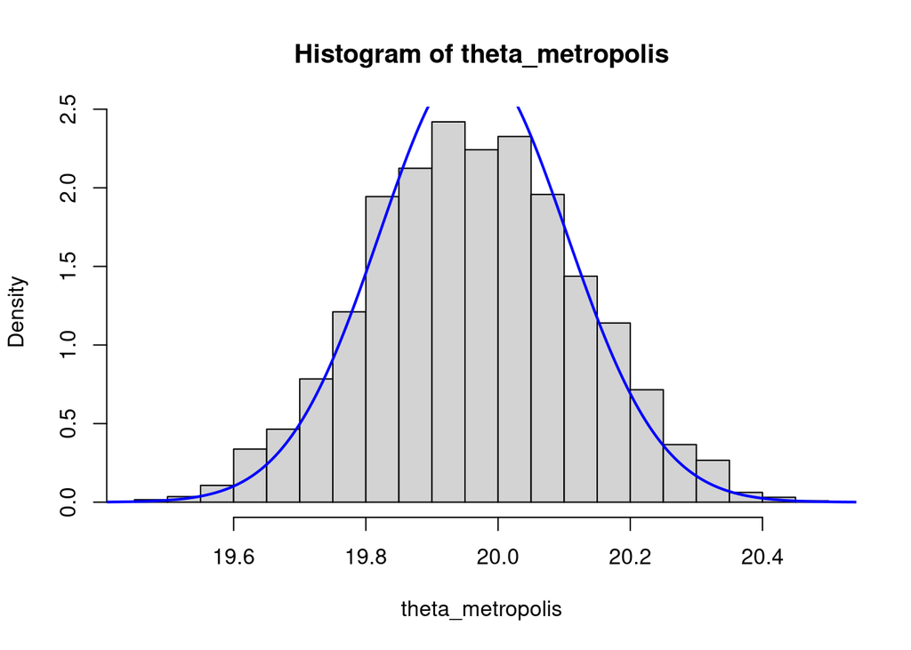

```r
h = hist(theta_metropolis, probability = TRUE)
xfit<-seq(theta_0-10,theta_0+10,length=T)
yfit<-dgamma(xfit,shape=sum(y), scale=1/n)
lines(xfit, yfit, col="blue", lwd=2)
```

La simulation avec l’algorithme métropolis correspond bien à la loi gamma démontrée dans la question 2.

## Question 6

Ici, on suppose que l’on tire des nouvelles valeurs (vecteur $y^*$)

On a $P(y^*|y)\propto\int_0^\infty P(y^*|\theta)P(\theta|y)d\theta$

$\propto\int_0^\infty \frac{\theta^{\sum_{i=1}^{n}y^*_i}}{\prod_{i=1}^{n}y^*_i!} e^{-n\theta} \theta^{\sum_{i=1}^{n}y_i-1} e^{-n\theta} \frac{n^{\sum_{i=1}^{n}y_i}}{\Gamma(\sum_{i=1}^{n}y_i)}d\theta$

$=\frac{n^{\sum_{i=1}^{n}y_i}}{(\prod_{i=1}^{n}y^*_i!) \Gamma(\sum_{i=1}^{n}y_i)}\int_0^\infty \theta^{\sum_{i=1}^{n}y^*_i +y_i-1}e^{-2n\theta}d\theta$

$=\frac{n^{\sum_{i=1}^{n}y_i}\Gamma(\sum_{i=1}^{n}y^*_i +y_i-1)}{(\prod_{i=1}^{n}y^*_i!) \Gamma(\sum_{i=1}^{n}y_i)}\frac{1}{(2n)^{\sum_{i=1}^{n}y^*_i +y_i-1}}$

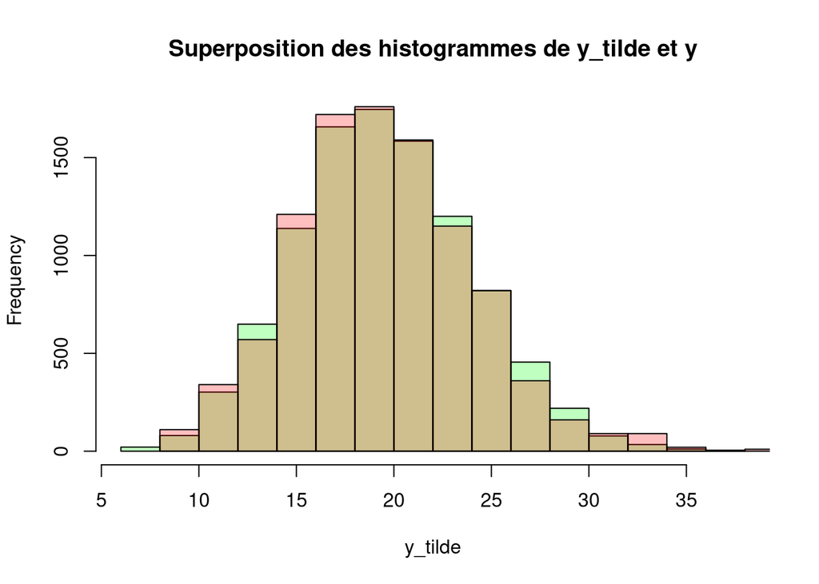

```r
#On simule theta
tab = algo_Metropolis(T+t_valeur,y,t_valeur)
# On simule
y_tilde = sapply(1:T, function(i) rpois(1, tab[i]))
h<-hist(y_tilde, plot = F)
h2 = hist(rep(y, T/length(y)), plot=F)
plot(h, col=rgb(0,1,0,1/4),main = "Superposition des histogrammes de y_tilde et y")
plot(h2, col=rgb(1,0,0,1/4), add=T)
```

Les deux histogrammes s’intersecte dans un large domaine. Ainsi les nouvelles données ressemblent aux données, ce qui valide le modèle et que le nombre d’itérations de l’algorithme apparaît suffisant.

Dans ce modèle, le choix d’une seule source loi de poisson peut étre critiquer généralement. Aussi, on peut mettre en question ce choix de la loi de Poisson en elle même.

### Partie2

## Question1

$P(y|z,\theta)=\prod_{i=1}^{n} P(y_i|z,\theta)=\prod_{i=1}^{n} P(y_i|z_i,\theta)$ car $z_i$ sufit pour déterminer $y_i$ puisque $P(y_i|z_i,\theta)$ est donnée.

Donc $P(y|z,\theta)=\prod_{i=1}^{n} (\theta_{z_i})^{y_i}\frac{e^{-\theta_{z_i}}}{y_i!}=\prod_{k=1}^{K} (\theta_{z_i=k})^{\sum_{i\in I_k}^{}y_i}\frac{e^{-\theta_k n_k}}{\prod_{i\in I_k}^{}y_i!}$, où $n_k=card(I_k)$

## Question 2

$P(z,\theta|y)=P(y|z,\theta)P(z,\theta)=P(y|z,\theta)P(z)P(\theta)$ car $z,\theta$ sont indépendantes.

Donc $P(z,\theta|y)\propto (\prod_{i=1}^{K} P(\theta_i))(\prod_{k=1}^{K} \theta_k^{\sum_{i\in I_k}^{} y_i}\frac{e^{-n_k\theta_k}}{\prod_{i\in I_k}^{}y_i!}) \propto \prod_{k=1}^{K}\theta_k^{\sum_{i\in I_k}^{} y_i-1}\frac{e^{-n_k\theta_k}}{\prod_{i\in I_k}^{}y_i!}$ car $P(\theta_i)=\frac{1}{\theta_i}$

## Question 3

$P(z_i=k|y,\theta)=P(z_i=k|y_i,\theta)$

En effet, la connaissance de $y_i,\theta$ permet de calculer la probabilité de $z_i=k$.

Donc les éléments $y_j$ tel que $j\ne i$ n’ajoute pas d’information pour l’évènement $(z_i=k)$.

Donc $P(z_i=k|y_i,\theta)=\frac{P(y_i|z_i=k,\theta)P(z_i=k)}{P(y_i,\theta)}=\frac{P(y_i|z_i=k,\theta)P(z_i=k)}{\sum_{j=1}^{K}P(y_i|z_i=j,\theta)P(z_i=j)}=\frac{P(y_i|z_i=k,\theta)}{\sum_{j=1}^{K}P(y_i|z_i=j,\theta)}=\frac{\frac{\theta^{y_i}_k}{y_i!}e^{-\theta_k}}{\sum_{j=1}^{K}\frac{\theta^{y_i}_j}{y_i!}e^{-\theta_j}}=\frac{\theta^{y_i}_ke^{-\theta_k}}{\sum_{j=1}^{K}\theta^{y_i}_je^{-\theta_j}}$

## Question 4

$P(\theta_k|y,z,\theta-k)\propto P(y|z,\theta_k,\theta-k)P(\theta_k)\propto P(y|z,\theta)\frac{1}{\theta_k}\propto \prod_{i\in I_k}^{}P(y_i|z,\theta)\frac{1}{\theta_k}$

$\propto \prod_{i\in I_k}^{}\theta^{\sum_{j\in I_k}y_j-1}_k e^{-\theta_k n_k}\propto \prod_{i\in I_k}^{}\theta^{n_k \bar{y_k}-1}_k e^{-\theta_k n_k}$

## Question 5

```r
K = 3;
y = c(rpois(100,6), rpois(500,20), rpois(250, 35) )
liste_y = list(y)
y = liste_y[[1]][sample(1:length(y))]

n = length(y);
algorithme_gibbs = function(t_valeur, T) {
  thetas = c(); proportions = c();
  #initialisation
  z = sample.int(K, n, replace = T)
  theta = sample(10, K, replace = T) + 3
    #simulation
  for (temps in 1:(t_valeur+T)) {
    z = sapply(1:n, function(i) sample.int(K, 1, prob = (theta ^ y[i]) * exp(- theta) ))
    theta = sapply(1:K, function(k) rgamma(1, shape = sum(y[z==k]), scale = 1/length(z[z==k])))
    if (temps>t_valeur){
      thetas = rbind(thetas, theta);
      proportions = rbind(proportions,sapply(1:K, function(x) length(z[z==x])+ 1e-06))
    }
  }
  return(list(thetas, proportions))
}
```

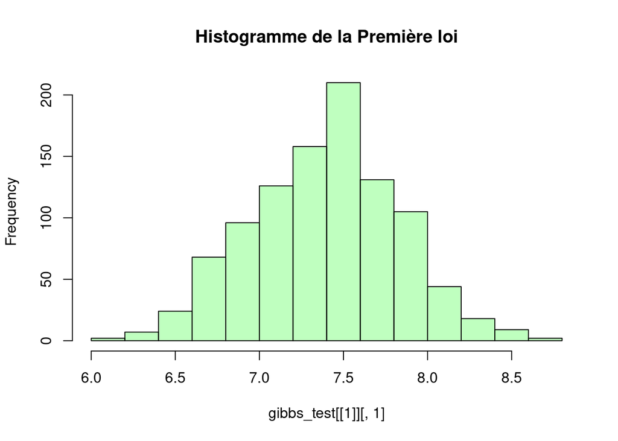

```r
gibbs_test = algorithme_gibbs(1000, 1000)
#print(gibbs_test)

plot(hist(gibbs_test[[1]][,1], plot = F), col=rgb(0,1,0,1/4),main = "Histogramme de la Première loi")
```

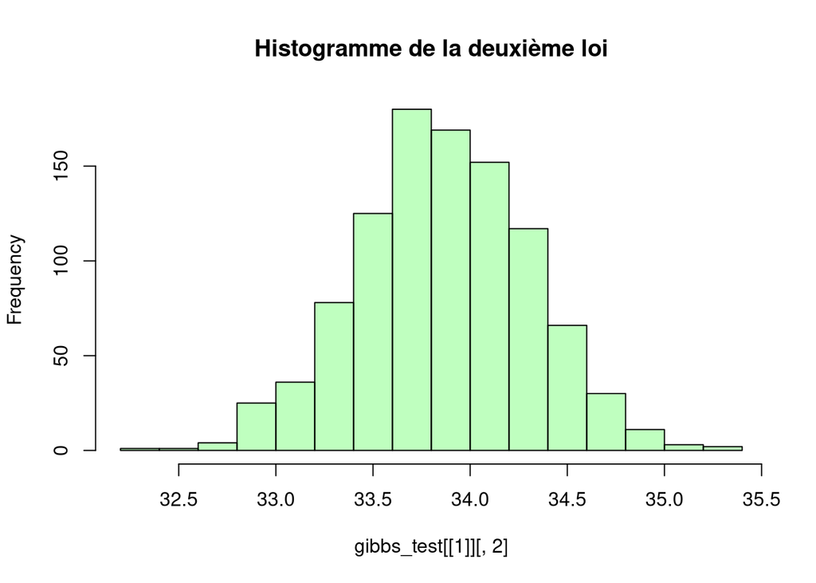

```r
plot(hist(gibbs_test[[1]][,2], plot = F), col=rgb(0,1,0,1/4),main = "Histogramme de la deuxième loi")
```

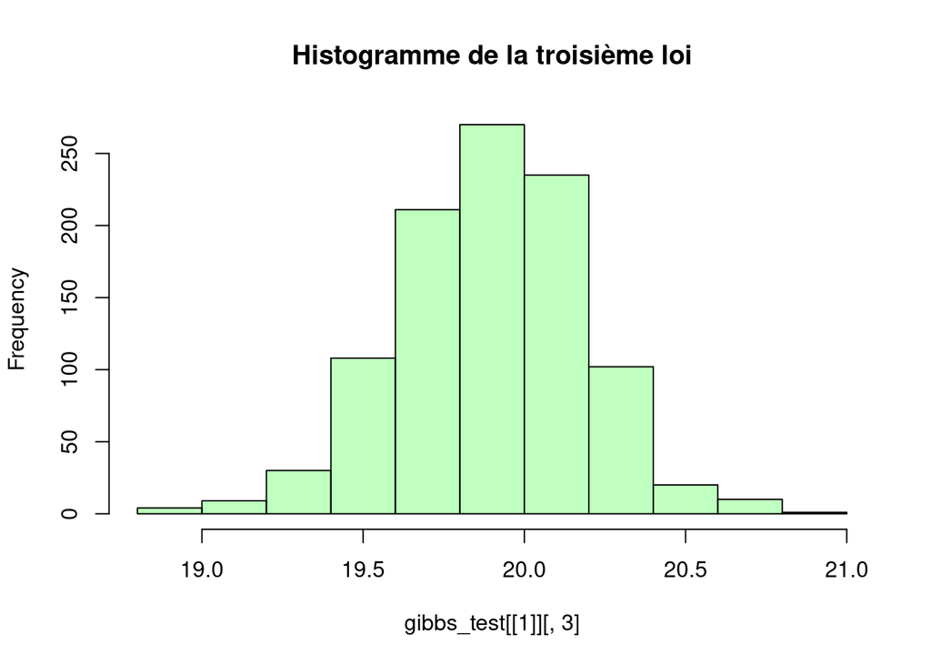

```r
plot(hist(gibbs_test[[1]][,3], plot = F), col=rgb(0,1,0,1/4),main = "Histogramme de la troisième loi")
```

## Question 6

Pour estimer la moyenne des parametres et proportions, on calcule la moyenne empiriques des simulations données par l’algo de Gibbs (On prend pas en compte les premieres valeurs dans les calcules, afin de supprimer l’effet de la condition intiale)

```r
r = algorithme_gibbs(1000, 1000)
theta = c(mean(r[[1]][,1]), mean(r[[1]][,2]), mean(r[[1]][,3]))
cat('Les espérances empiriques de theta_k :', sort(theta))
```

```
## Les espérances empiriques de theta_k : 7.414287 19.90894 33.86781
```

```r
cat("\n")
```

```r
prop = c(mean(r[[2]][,1]), mean(r[[2]][,2]), mean(r[[2]][,3]))
prop = prop/sum(prop)
cat('Les proportions de chaque composante du mélange :', sort(prop))
```

```
## Les proportions de chaque composante du mélange : 0.1546635 0.3435788 0.5017576
```

## Question 7

```r
K = 3
y = scan("TP3_mpa_2020.txt");
n = length(y);

loi_melange <-function(x,theta,proportion){
  sum = rep(0, length(x))
  for(j in (1:length(x))){
    for( i in (1 : length(theta))){
      sum[j] = sum[j]+ dpois(x[j],theta[i])*proportion[i]
    }
}
  return(sum)
}


K = 3
r = algorithme_gibbs(1000, 1000)
theta = c(mean(r[[1]][,1]), mean(r[[1]][,2]), mean(r[[1]][,3]))
prop = c(mean(r[[2]][,1]), mean(r[[2]][,2]), mean(r[[2]][,3])); prop = prop/sum(prop)
y_pour_k_3 =  loi_melange( (1:max(y)), theta, prop)

K = 4
r = algorithme_gibbs(1000, 1000)
theta = c(mean(r[[1]][,1]), mean(r[[1]][,2]), mean(r[[1]][,3]))
prop = c(mean(r[[2]][,1]), mean(r[[2]][,2]), mean(r[[2]][,3])); prop = prop/sum(prop)
y_pour_k_4 = loi_melange( (1:max(y)), theta, prop )

K = 5
r = algorithme_gibbs(1000, 1000)
theta = c(mean(r[[1]][,1]), mean(r[[1]][,2]), mean(r[[1]][,3]))
prop = c(mean(r[[2]][,1]), mean(r[[2]][,2]), mean(r[[2]][,3])); prop = prop/sum(prop)
y_pour_k_5 = loi_melange( (1:max(y)), theta, prop  )
```

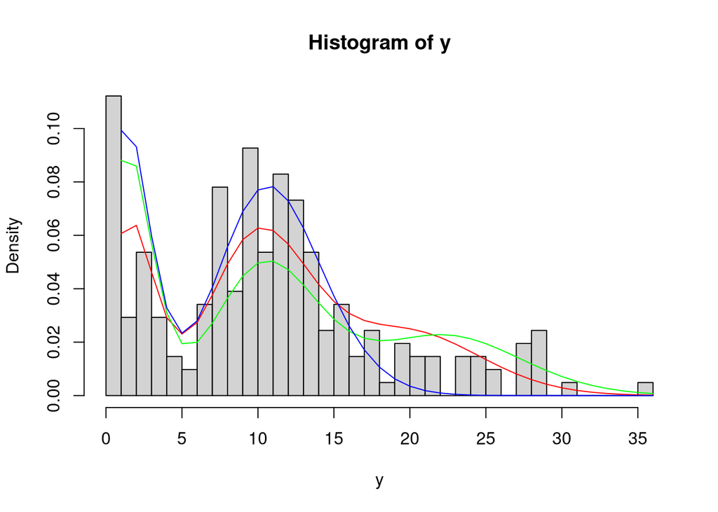

```r
hist(y, probability = T, breaks = seq(0, max(y), by = 1))
lines((1:max(y)), y_pour_k_3, col="red")
lines((1:max(y)), y_pour_k_4, col="green")
lines((1:max(y)), y_pour_k_5, col="blue")
```

Une version améliorée de l’algorithme de Gibbs, faisant intervenir la variable g=(g1,…,gK) pour représenter les proportions des classes. On refait les calculs précédents on faisant intervenir g:

$P(\theta_k|y,z,\theta_{-k},\pi)=P(\theta_k|y,z,\theta_{-k})$

$P(z_i=k|y,\theta,g_k)=\frac{P(y_i|z_i=k,\theta)g_k}{\sum_{l=1}^{K}P(y_i|z_i=l,\theta)g_l}=\frac{\theta_k^{y_i}e^{-\theta_k}g_k}{\sum_{l=1}^{K}\theta_l^{y_i}e^{-\theta_l}g_l}$

$P(g|y,z,\theta)=P(g|z)=\prod_{k=1}^{K}P(g_k|z)$

$\propto\prod_{k=1}^{K}P(z|g_k)P(g_k)$

$\propto\prod_{k=1}^{K}P(z|g_k)$

$\propto\prod_{i=1}^{K}\prod_{i\in I_k}^{}P(z_i|g_k)\prod_{i\notin I_k}^{}P(z_i)$

$\propto\prod_{i=1}^{K}\prod_{i\in I_k}^{}P(z_i|g_k)$

$\propto\prod_{i=1}^{K}g_k^{n_k}$

$\pi|y,z,\theta \sim Dir(1+n_1,...,1+n_K)$ L’algo a donc 3 étapes :

GS1 : simuler zi pour tout i sachant la loi p(zi=k|y,θ)

GS2 : simuler θk sachant y,z,θ−k

GS3 : simuler g selon la loi de Dirichlet.